# Exploration of Metabolite Levels Across the Brains of Rats Treated with Varriable Doses of DMSO

March 15, 2019

## Data Tidying

## Description of the Data

The data was came as an excel file that was not #Tidy at all.

-data (treatment) was stored in column names, not as a vector -this occured across 3 parts of the data: -the mean intensity -the p-value -the fold change -vector names are full of "."s and spaces, which will cause problems with ggplot

## How we Tidyd the data

```r
Untidy_DMSO_Data
```

```
## # A tibble: 1,472 x 13
##    Region    ID ChemicalName mean.Control.PBS mean.0.2.mg.kg.~
##    <chr>  <dbl> <chr>                   <dbl>            <dbl>
##  1 Hippo~    25 alpha-Guani~         5868675.         7358415.
##  2 Cortex    25 alpha-Guani~         4531331.         5744252.
##  3 Cereb~    25 alpha-Guani~         4440230          4729836.
##  4 Basal~    25 alpha-Guani~         6141963.         6627735
##  5 Hippo~    26 alpha-Guani~        23902026.        17344093.
##  6 Cortex    26 alpha-Guani~        29890478.        21407947.
##  7 Cereb~    26 alpha-Guani~        26818103.        16010817.
##  8 Basal~    26 alpha-Guani~        26768719.        26497697.
##  9 Hippo~    27 beta-D-Gluc~        13132860.        12968494.
## 10 Cortex    27 beta-D-Gluc~        11608789.        12083229
## # ... with 1,462 more rows, and 8 more variables:
## #   mean.2.0.mg.kg.DMSO <dbl>, mean.4.0.mg.kg.DMSO <dbl>,
## #   FC_lowvsCTRL <dbl>, FC_medvsCTRL <dbl>, FC_highvsCTRL <dbl>,
## #   post.hoc.Control.PBS.0.2.mg.kg.DMSO <dbl>,
## #   post.hoc.Control.PBS.2.0.mg.kg.DMSO <dbl>,
## #   post.hoc.Control.PBS.4.0.mg.kg.DMSO <dbl>
```

## How we #Tidyd the data

Oof, those column names have to go

```r
colnames(Untidy_DMSO_Data)
```

```
##  [1] "Region"
##  [2] "ID"
##  [3] "ChemicalName"
##  [4] "mean.Control.PBS"
##  [5] "mean.0.2.mg.kg.DMSO"
##  [6] "mean.2.0.mg.kg.DMSO"
##  [7] "mean.4.0.mg.kg.DMSO"
##  [8] "FC_lowvsCTRL"
##  [9] "FC_medvsCTRL"
## [10] "FC_highvsCTRL"
## [11] "post.hoc.Control.PBS.0.2.mg.kg.DMSO"
## [12] "post.hoc.Control.PBS.2.0.mg.kg.DMSO"
## [13] "post.hoc.Control.PBS.4.0.mg.kg.DMSO"
```

## How we #Tidyd the data

```r
Untidy_DMSO_Data <- Untidy_DMSO_Data %>%
  rename(
          "Chemical_Name" = ChemicalName,
          "Mean_Intensity_Control" = mean.Control.PBS,
          "Mean_Intensity_02" = mean.0.2.mg.kg.DMSO,
          "Mean_Intensity_20" = mean.2.0.mg.kg.DMSO,
          "Mean_Intensity_40" = mean.4.0.mg.kg.DMSO,
          "Fold_Change_02" = FC_lowvsCTRL,
          "Fold_Change_20" = FC_medvsCTRL,
          "Fold_Change_40" = FC_highvsCTRL,
          "p_val_02" = post.hoc.Control.PBS.0.2.mg.kg.DMSO,
          "p_val_20" = post.hoc.Control.PBS.2.0.mg.kg.DMSO,
          "p_val_40" = post.hoc.Control.PBS.4.0.mg.kg.DMSO
          )
```

## How we #Tidyd the data

Much Better!

```r
colnames(Untidy_DMSO_Data)
```

```
##  [1] "Region"                 "ID"
##  [3] "Chemical_Name"          "Mean_Intensity_Control"
##  [5] "Mean_Intensity_02"      "Mean_Intensity_20"
##  [7] "Mean_Intensity_40"      "Fold_Change_02"
##  [9] "Fold_Change_20"         "Fold_Change_40"
## [11] "p_val_02"               "p_val_20"
## [13] "p_val_40"
```

Now we need to Gather some columns

## How we #Tidyd the data

We gathered intensities and made a data frame with **only** intensities

```r
Intensity_DMSO_Data<- Untidy_DMSO_Data %>%
   #Gathers 4 columns
   gather(Mean_Intensity_Control,
         Mean_Intensity_02,
         Mean_Intensity_20,
         Mean_Intensity_40,
         key="Treatment", value="Mean_Intensity")%>%

   #deletes part of unwanted text in data
   separate(Treatment,
            into= c("Delete", "Treatment"),
            sep = "_Intensity_") %>%

   # selects 3 "key" columns, treatment, and intensity
   select(Region, ID, Chemical_Name, Treatment, Mean_Intensity)
```

## How we #Tidyd the data

We gathered fold changes and made a data frame with **only** fold changes

```r
Fold_Change_DMSO_Data<- Untidy_DMSO_Data %>%
 #Gathers 4 columns
   gather(Fold_Change_02,
           Fold_Change_20,
           Fold_Change_40,
          key="Treatment", value="Fold_Change_vs_Control") %>%

 #deletes part of unwanted text in data
 separate(Treatment,
            into= c("Delete", "Treatment"),
            sep = "_Change_") %>%

 # selects 3 "key" columns, treatment, and intensity
 select(Region, ID, Chemical_Name, Treatment, Fold_Change_vs_Control)
```

## How we #Tidyd the data

We gathered p-values and made a data frame with **only** p-values

```r
p_value_DMSO_Data<- Untidy_DMSO_Data %>%
 #Gathers 3 columns
 gather(p_val_02,
        p_val_20,
        p_val_40,
        key="Treatment", value="p_value_vs_Control") %>%

 #deletes part of unwanted text in data
 separate(Treatment,
            into= c("Delete", "Treatment"),
            sep = "_val_") %>%
 # selects 3 "key" columns, treatment, and intensity
 select(Region, ID, Chemical_Name, Treatment, p_value_vs_Control)
```

## How we #Tidyd the data

So Each Table looks something like this, but we need to join all of the tables by the key : Chemical Name, ID, and Region

```r
p_value_DMSO_Data
```

```
## # A tibble: 4,416 x 5
##    Region          ID Chemical_Name             Treatment p_value_vs_Contr~
##    <chr>        <dbl> <chr>                     <chr>                 <dbl>
##  1 Hippocampus     25 alpha-Guanidinoglutaric-~ 02                    0.608
##  2 Cortex          25 alpha-Guanidinoglutaric-~ 02                    0.810
##  3 Cerebellum      25 alpha-Guanidinoglutaric-~ 02                    1.000
##  4 Basal Gangl~    25 alpha-Guanidinoglutaric-~ 02                    0.977
##  5 Hippocampus     26 alpha-Guanidinoglutaric-~ 02                    0.836
##  6 Cortex          26 alpha-Guanidinoglutaric-~ 02                    0.628
##  7 Cerebellum      26 alpha-Guanidinoglutaric-~ 02                    0.413
##  8 Basal Gangl~    26 alpha-Guanidinoglutaric-~ 02                    0.997
##  9 Hippocampus     27 beta-D-Glucose            02                    0.982
## 10 Cortex          27 beta-D-Glucose            02                    0.995
## # ... with 4,406 more rows
```

## How we #Tidyd the data

So Each Table looks something like this, but we need to join all of the tables by the key : Chemical Name, ID, and Region Join!: join treatment and Fold Change, and p_val

```r
Tidy_DMSO_Data <- left_join(Intensity_DMSO_Data, Fold_Change_DMSO_Data)
Tidy_DMSO_Data <- left_join(Tidy_DMSO_Data, p_value_DMSO_Data)
```

## How we #Tidyd the data

So Each Table looks something like this, but we need to join all of the tables by the key : Chemical Name, ID, and Region Join!: join treatment and Fold Change, and p_val

```r
head(Tidy_DMSO_Data)
```

```
## # A tibble: 6 x 7
##   Region    ID Chemical_Name Treatment Mean_Intensity Fold_Change_vs_~
##   <chr>  <dbl> <chr>         <chr>              <dbl>            <dbl>
## 1 Hippo~    25 alpha-Guanid~ Control         5868675.               NA
## 2 Cortex    25 alpha-Guanid~ Control         4531331.               NA
## 3 Cereb~    25 alpha-Guanid~ Control         4440230                NA
## 4 Basal~    25 alpha-Guanid~ Control         6141963.               NA
## 5 Hippo~    26 alpha-Guanid~ Control        23902026.               NA
## 6 Cortex    26 alpha-Guanid~ Control        29890478.               NA
## # ... with 1 more variable: p_value_vs_Control <dbl>
```

## Subsets of the Data

## Subsets of the Data

-Our data set was very large, so we took subsets of the data

## Subsets of the Data

```r
Chems_in_OneCMetabolism <-
  Tidy_DMSO_Data %>%
  filter(Chemical_Name== "Cystathionine" |
        Chemical_Name== "DL-Cystathionine" |
        Chemical_Name== "S-Adenosyl-homocysteine" |
        Chemical_Name== "S-Adenosyl-methionine" |
        Chemical_Name== "S-Lactoylglutathione" |
        Chemical_Name== "Glutathione-oxidized" |
        Chemical_Name== "Glutathione-reduceD-")
Chems_in_OneCMetabolism
```

```
## # A tibble: 128 x 7
##    Region    ID Chemical_Name Treatment Mean_Intensity Fold_Change_vs_~
##    <chr>  <dbl> <chr>         <chr>              <dbl>            <dbl>
##  1 Hippo~   140 Cystathionine Control         7624556.               NA
##  2 Cortex   140 Cystathionine Control         6559004.               NA
##  3 Cereb~   140 Cystathionine Control        51973481.               NA
##  4 Basal~   140 Cystathionine Control         7466175                NA
##  5 Hippo~   156 DL-Cystathio~ Control         1089096.               NA
##  6 Cortex   156 DL-Cystathio~ Control          844637.               NA
##  7 Cereb~   156 DL-Cystathio~ Control         2966365.               NA
##  8 Basal~   156 DL-Cystathio~ Control          952557.               NA
##  9 Hippo~   182 Glutathione-~ Control           43738                NA
## 10 Cortex   182 Glutathione-~ Control           65481                NA
## # ... with 118 more rows, and 1 more variable: p_value_vs_Control <dbl>
```

## Subsets of the Data

```r
Chems_in_Nucleotides <-
  Tidy_DMSO_Data %>%
  filter(Chemical_Name== "5-Methylcytidine" |
        Chemical_Name== "5-Methylcytosine" |
        Chemical_Name== "7-Methylguanine" |
        Chemical_Name== "7-Methylguanosine" |
        Chemical_Name== "Adenine" |
        Chemical_Name== "Adenosine" |
        Chemical_Name== "Adenosine-3-monophosphate" |
        Chemical_Name== "beta-Nicotinamide-adenine-dinucleotide" |
        Chemical_Name== "Guanine" |
        Chemical_Name== "Guanosine" |
        Chemical_Name== "Guanosine-5-tetraphosphate" |
        Chemical_Name== "Cytidine" |
        Chemical_Name== "Cytidine-5-diphosphate-ethanolamine" |
        Chemical_Name== "METHYLGUANIDINE" |
        Chemical_Name== "2-Methylguanosine" |
        Chemical_Name== "Nicotinamide-riboside-cation" |
        Chemical_Name== "Thymine" |
        Chemical_Name== "UMP" |
        Chemical_Name== "3-Methylcytidine" |
        Chemical_Name== "2-Deoxycytidine" |
        Chemical_Name== "2-O-Methylcytidine" |
        Chemical_Name== "3-O-Methylcytidine" |
        Chemical_Name== "Uracil" |
        Chemical_Name== "Uridine" |
        Chemical_Name== "1-Methyladenosine" |
        Chemical_Name== "Xanthine" |
        Chemical_Name== "Xanthosine-5-monophosphate" |
        Chemical_Name== "Inosine" |
        Chemical_Name== "Inosine-5-monophosphate" |
        Chemical_Name== "5-Methylthioadenosine" |
        Chemical_Name== "5-S-Methyl-5-thioadenosine" |
        Chemical_Name== "Uridine-5-diphosphoacetylglucosamine" )
Chems_in_Nucleotides
```

```
## # A tibble: 512 x 7
##    Region    ID Chemical_Name Treatment Mean_Intensity Fold_Change_vs_~
##    <chr>  <dbl> <chr>         <chr>              <dbl>            <dbl>
##  1 Hippo~    98 Adenine       Control           62611                NA
##  2 Cortex    98 Adenine       Control           81756.               NA
##  3 Cereb~    98 Adenine       Control           65762.               NA
##  4 Basal~    98 Adenine       Control           72556                NA
##  5 Hippo~    99 Adenosine     Control        25783745                NA
##  6 Cortex    99 Adenosine     Control        39391868.               NA
##  7 Cereb~    99 Adenosine     Control        32699936.               NA
##  8 Basal~    99 Adenosine     Control        22373027.               NA
##  9 Hippo~   101 Adenosine-3-~ Control          476597.               NA
## 10 Cortex   101 Adenosine-3-~ Control          273114.               NA
## # ... with 502 more rows, and 1 more variable: p_value_vs_Control <dbl>
```

## Subsets of the Data

This is just metabolites with significant p-values and fold changes. Significant p-val is 0.05, significant fold change = 2

```r
DMSO_Data_Sig_Foldchange_AND_pval <- Tidy_DMSO_Data %>%
  select(Chemical_Name,
         Region,
         Fold_Change_vs_Control,
         p_value_vs_Control,
         Mean_Intensity,
         Treatment) %>%
  filter(Fold_Change_vs_Control >= 2.0 & p_value_vs_Control <= 0.05)
```

## Visualization

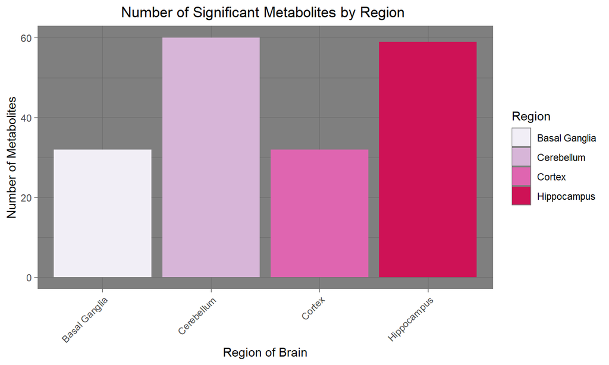

```r
DMSO_Data_Sig_Foldchange_AND_pval%>%
  ggplot(aes(x= Region, fill=Region))+
  geom_bar()+
  theme_dark()+
  theme(legend.position = "right",
        axis.text.x = element_text(angle = 45, hjust=1))+
  labs(title = "Number of Significant Metabolites by Region ",
       x = "Region of Brain",
       y = "Number of Metabolites")+
  theme(plot.title = element_text(hjust = 0.5))+
  scale_fill_brewer(palette = "PuRd")
```

## Visualization

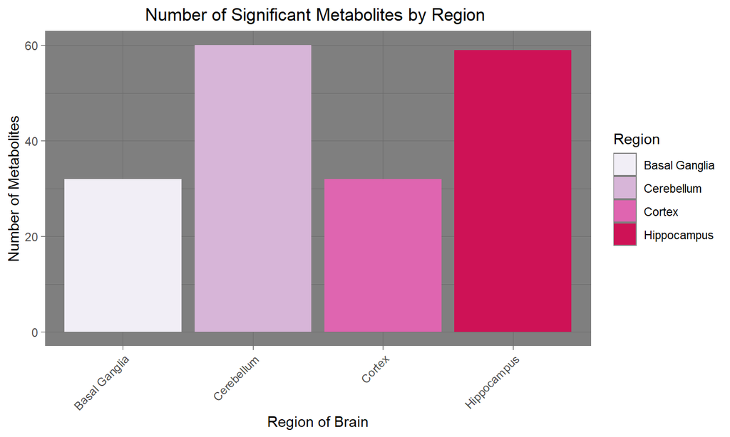

## Visualization

Looking at the relationship between SAM and SAH is a common indicator on where the equalibrium lays and is idiciative of the activity of the metabolomic pathway

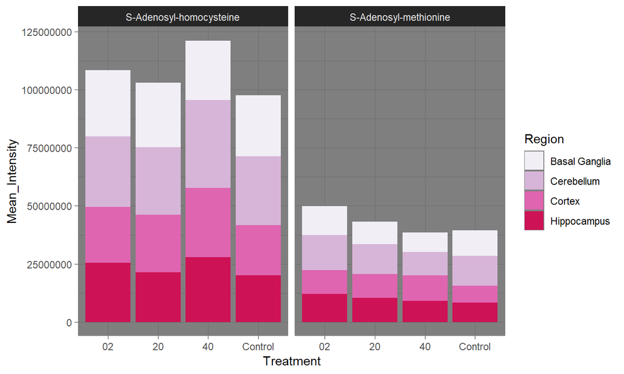

```r
Chems_in_OneCMetabolism %>%
    filter(Chemical_Name== "S-Adenosyl-homocysteine" |
           Chemical_Name== "S-Adenosyl-methionine") %>%
    ggplot(aes(x = Treatment, y = Mean_Intensity, fill = Region))+
    geom_bar(stat = "identity")+
    theme(axis.text.x = element_text(angle = 60, hjust=1))+
    theme_dark()+
    scale_fill_brewer(palette="PuRd")+
    facet_grid(~Chemical_Name)
```

## Visualization

Looking at the relationship between SAM and SAH is a common indicator on where the equalibrium lays and is idiciative of the activity of the metabolomic pathway

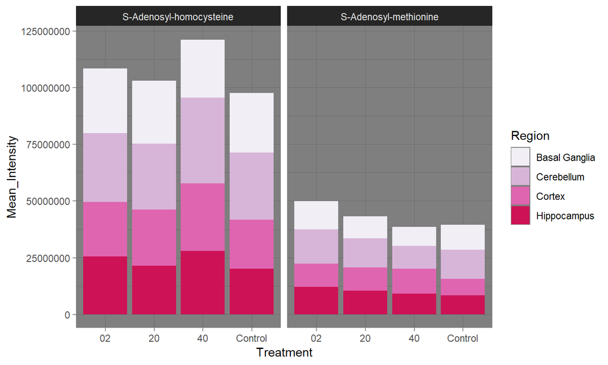

## Visualization

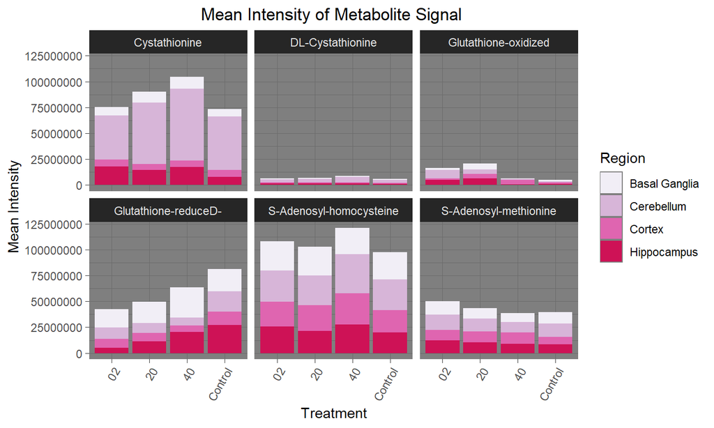

## Visualization

[output not shown]

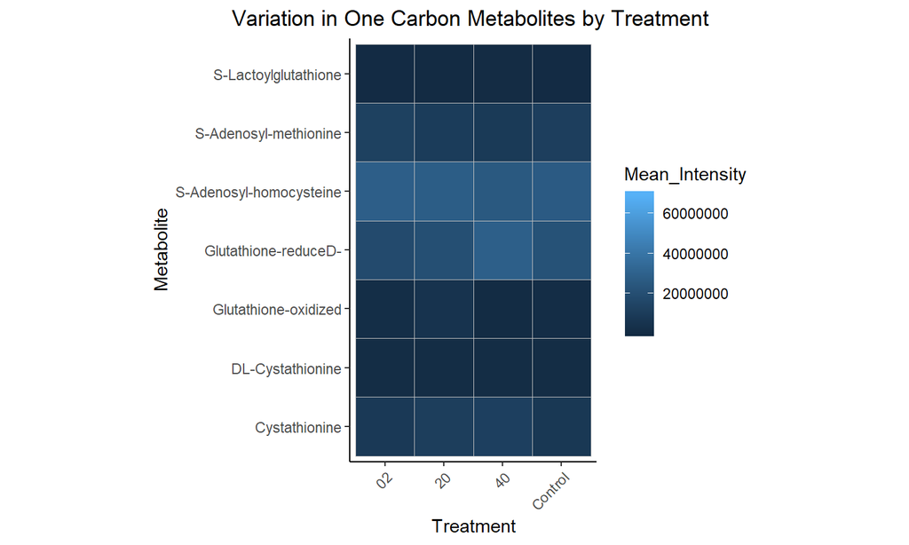

```r
Chems_in_OneCMetabolism %>%
  ggplot(aes(x=Treatment, y=Chemical_Name))+
  theme_classic(base_family = "Avenir")+
  geom_tile(aes(fill= Mean_Intensity), color="grey")+
  theme(legend.position = "right",
        axis.text.x = element_text(angle = 45, hjust=1))+
  coord_fixed()+ #maintains aspect ratio so 1 unit on x is 1 unit on y
  labs(title = "Variation in One Carbon Metabolites by Treatment ",
       x = "Treatment",
       y = "Metabolite")+
  theme(plot.title = element_text(hjust = 0.5))
```

## Visualization

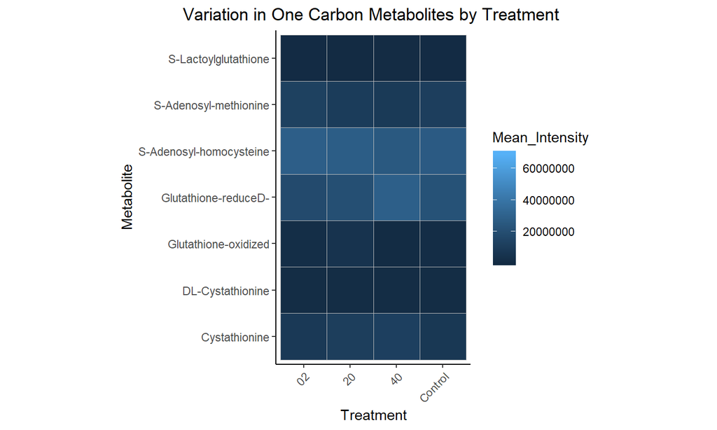

## Visualization

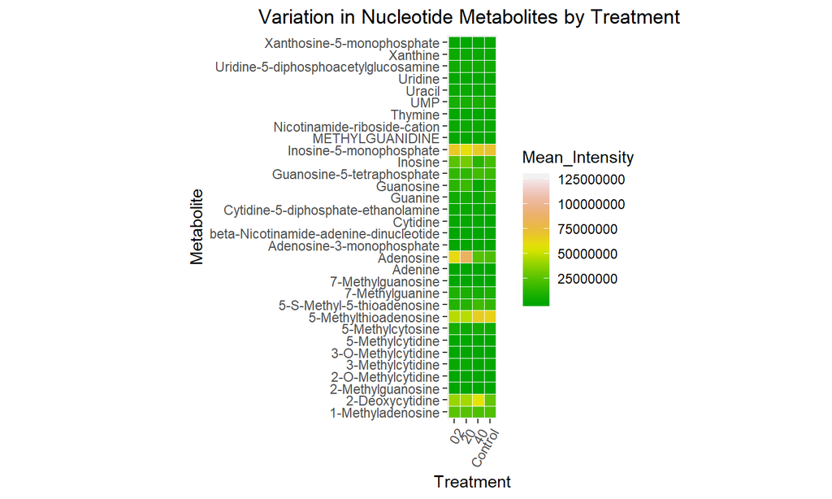

```r
Chems_in_Nucleotides %>%
ggplot(aes(x=Treatment, y=Chemical_Name))+
  geom_tile(aes(fill=Mean_Intensity), color="white")+
  theme(legend.position = "right",
        axis.text.x = element_text(angle = 60, hjust=1),
        plot.title = element_text(hjust = 0.5))+
  coord_fixed()+ #maintains aspect ratio so 1 unit on x is 1 unit on y
  labs(title = "Variation in Nucleotide Metabolites by Treatment ",
       x = "Treatment",
       y = "Metabolite")+
scale_fill_gradientn(colours = terrain.colors(19))
```

## Visualization

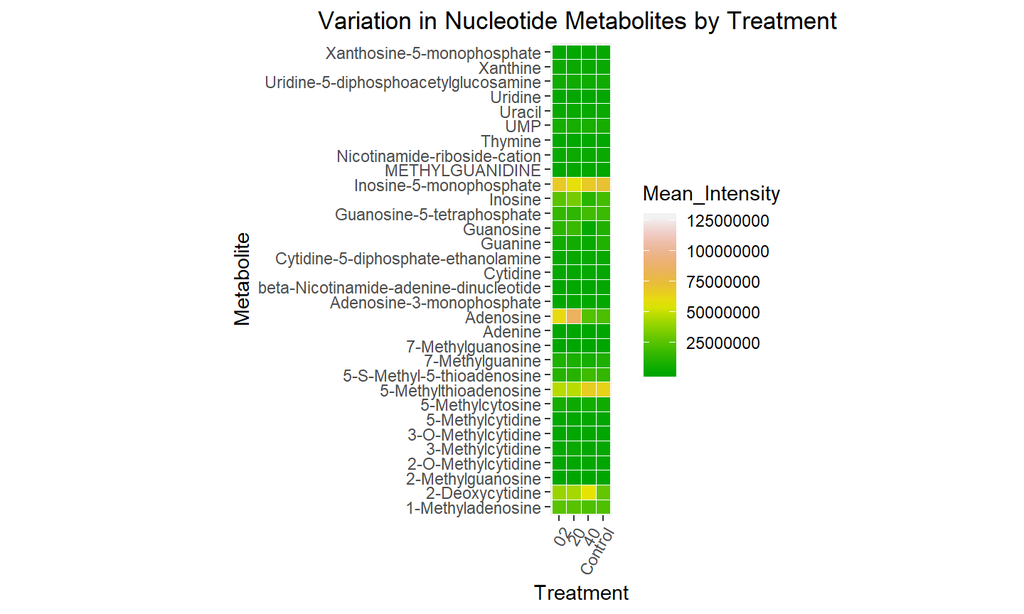